# Teste para vaga de Cientista de Dados

Claudio Lobenwein Resende

05/03/2020

# Uso da Wikipedia como recurso de ensino

O texto a seguie apresenta análises descritivas e preditivas acerca da percepção de professores universitário quanto ao uso da Wikipedia como recurso de ensino. A pesquisa foi desenvolvida por professores da Universitat Oberta de Catalunya, Barcelona, Espanha. A base foi baixada no endereço http://archive.ics.uci.edu/ml/datasets/wiki4HE.

O texto a seguir apresenta uma análise de dados sobre a percepção de professores universitários acerca do uso da plataforma Wikipedia como ferramenta de ensino. Foram entrevistados 913 professores de diferentes áreas de ensino, idades e experiência acadêmica, formação (possui ou não doutorado), bem como se são usuários registrados da plataforma Wikipedia ou não.

A análise a seguir está centrada nas características básicas dos professores e na relação entre essas características e a percepção sobre a satisfação com o uso da plataforma como ferramenta de ensino (perceived enjoyment). A pergunta que se quer responder é se essa percepção muda de acordo com os diferentes perfis de docentes, como gênero, idade, tempo de experiência acadêmica e área de ensino. Para isso, é necessário compreender o perfil dos professores.

Os dois gráficos a seguir apresentam a distribuição dos professores pesquisados quanto ao gênero e quanto ao perfil de uso da plataforma (usuários e não-usuários). O que se percebe quanto ao gênero é que a distribuição é relativamente equitativa (57,5% de homens e 42,5% de mulheres). Uma análise dessa variável com as demais variáveis descritivas do público pesquisado não apresentou resultados relevantes.

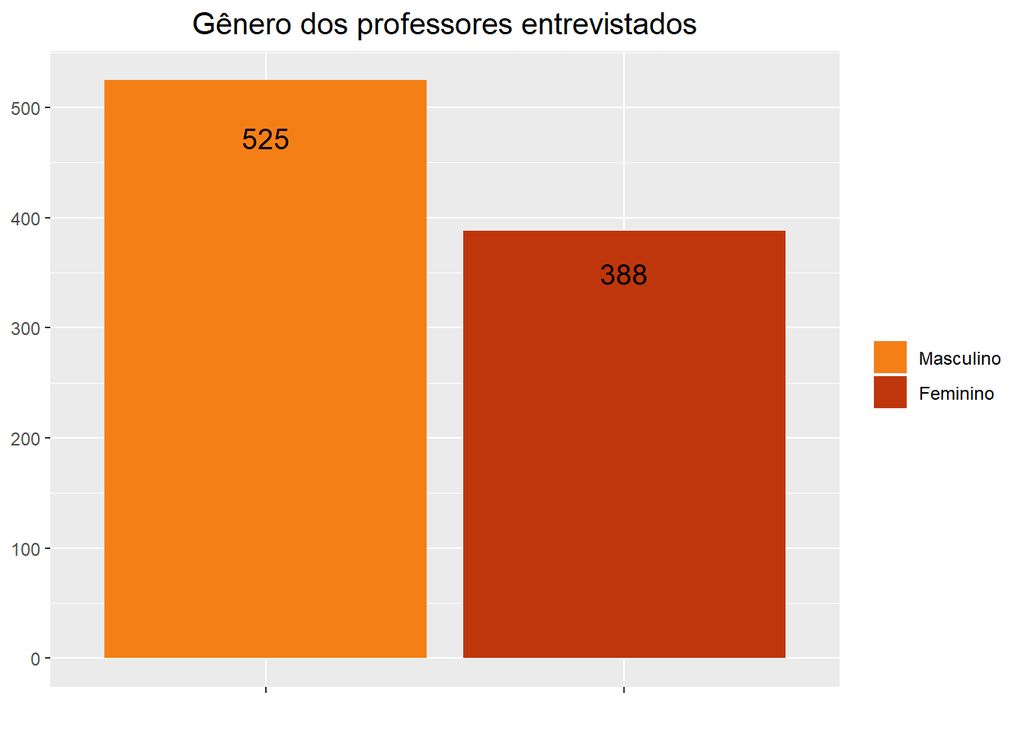

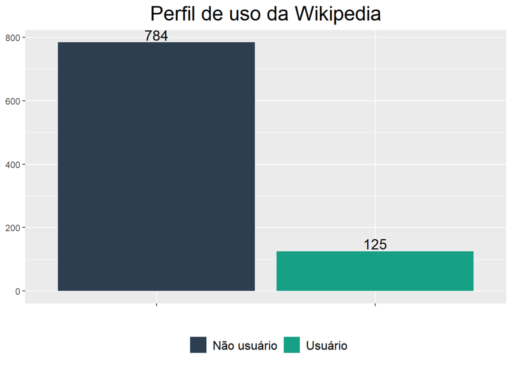

Entre os pesquisados, apenas 13,7% se disseram usuários registrados da Wikipedia, ao passo que 85,9% disseram não ser usuários. Esses números são por si um resultado relevante, tendo em vista que a forma de uso da plataforma pode afetar a visão que as pessoas têm em relação ao seu uso como ferramenta complementar de ensino, como será visto mais à frente.

Em relação à idade, é interessante observar que os dados possuem uma distribuição próxima a uma distribuição normal, em que os valores estão concentrados em torno da média. Ainda, em uma distribuição normal, a mediana e a moda possuem o mesmo valor da média. Nos dados de idade analisados, esses três valores se aproximam, sendo a média igual 42,25, a mediana igual a 42 e a moda igual a 43.

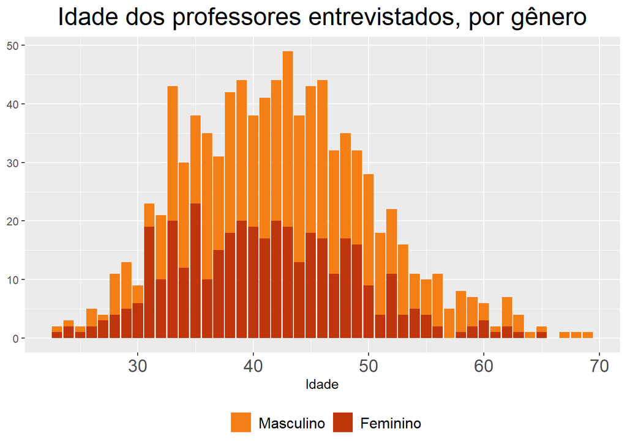

```
##    Min. 1st Qu.  Median    Mean 3rd Qu.    Max.
##   23.00   36.00   42.00   42.25   47.00   69.00
```

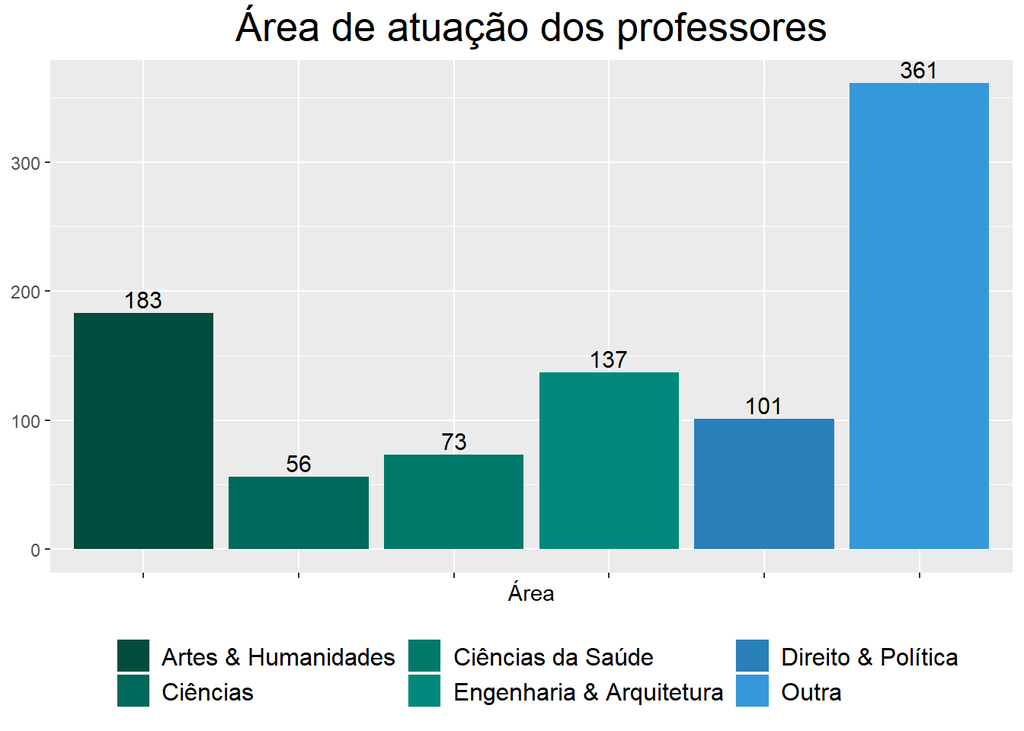

## Satisfação percebida (perceived enjoyness)

Os professores pesquisados responderam a 43 afirmações, distribuídas entre 13 grupos, sobre o uso da Wikipedia como ferramenta de ensino. As afirmações deveriam ser respondidas em uma escala de Likert de 1 a 5, em que 1 significa “discorda muito” e 5 significa “concorda muito”. A análise de todas essas perguntas foge ao escopo desse texto, mas é importante destacar que o conjunto de perguntas deve ser analisado como um todo, tendo em vista se tratar de perguntas que se relacionam e que podem fornecer uma visão mais detalhada dos resultados.

A análise aqui se concentra na satisfação percebida (perceived enjoyness), composto por duas perguntas: * 1. o uso da Wikipedia estimula a curiosidade; e * 2. o uso da Wikipedia é divertido (entertaining)

A primeira pergunta (ENJ1) possui uma média igual a 3,79, considerando-se os valores da escala de Likert. A pergunta ENJ2 possui a média igual 3,82. Ou seja, em geral, os professores tendem a concordar com as afirmações sobre a satisfação com uso da Wikipedia, mas possuem alguma relutância quanto ao seu uso.

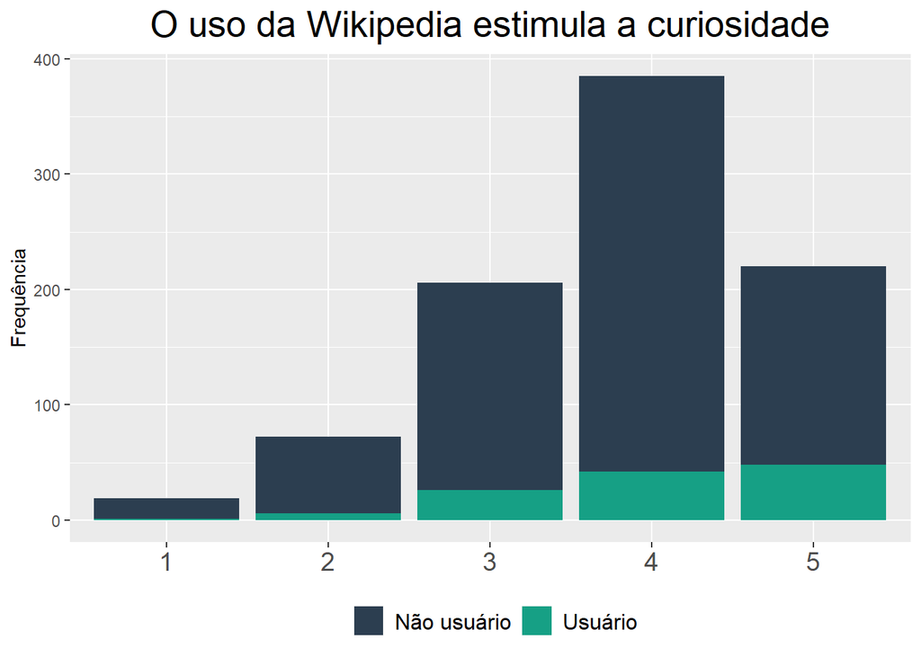

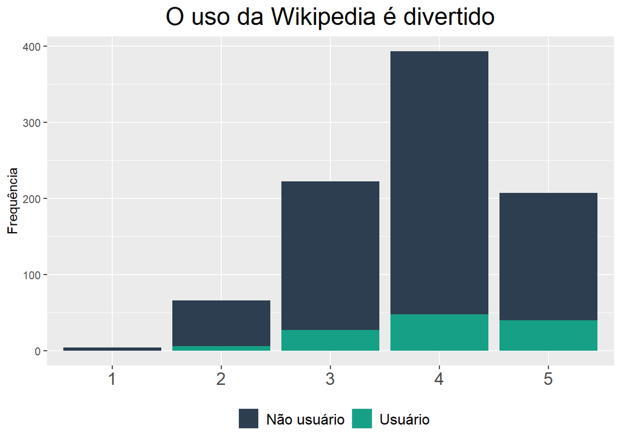

Quando essas afirmações são analisadas considerando-se o perfil de uso (usuário e não usuário), percebe-se uma tendência maior de concordância entre os professores que são usuários registrados.

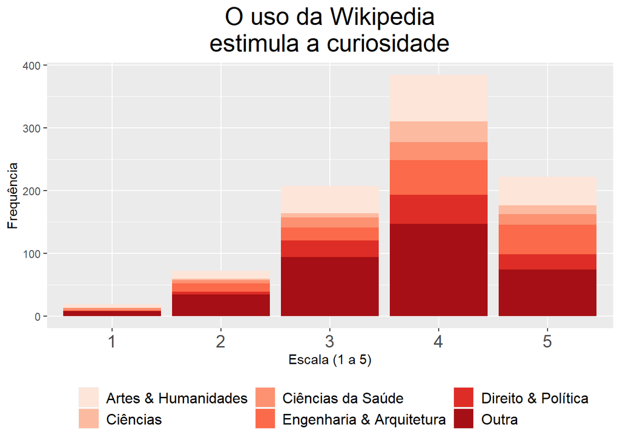

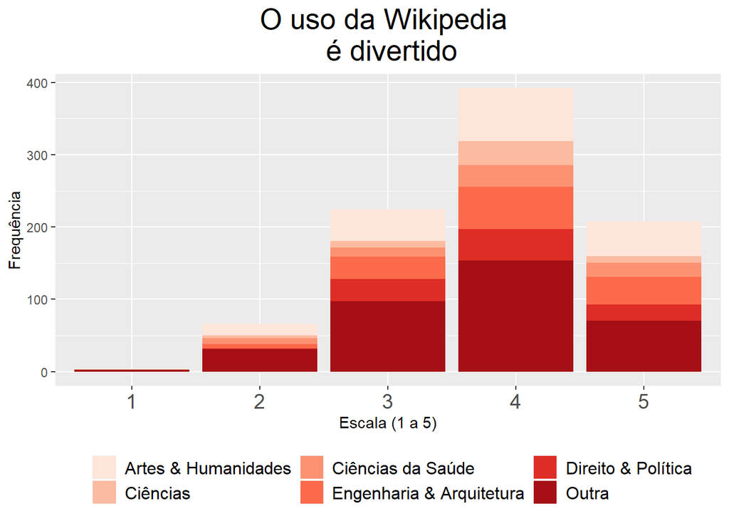

```
##
## Call:
## glm(formula = base$ENJ1Recod ~ base$AGE + base$GENDER + base$DOMAIN +
##     base$PhD + base$YEARSEXP + base$UNIVERSITY + base$UOC_POSITION,
##     family = binomial(link = "logit"))
##
## Deviance Residuals:
##     Min       1Q   Median       3Q      Max
## -2.2162  -1.3321   0.7733   0.9441   1.3818
##
## Coefficients: (1 not defined because of singularities)
##                      Estimate Std. Error z value Pr(>|z|)
## (Intercept)         1.680e+01  1.029e+03   0.016 0.986968
## base$AGE           -3.150e-02  9.368e-03  -3.362 0.000774 ***
## base$GENDER        -2.383e-01  1.546e-01  -1.541 0.123283
## base$DOMAIN1       -1.502e+01  1.029e+03  -0.015 0.988349
## base$DOMAIN2       -1.415e+01  1.029e+03  -0.014 0.989027
## base$DOMAIN3       -1.507e+01  1.029e+03  -0.015 0.988316
## base$DOMAIN4       -1.481e+01  1.029e+03  -0.014 0.988513
## base$DOMAIN5       -1.496e+01  1.029e+03  -0.015 0.988396
## base$DOMAIN6       -1.526e+01  1.029e+03  -0.015 0.988163
## base$PhD           -1.583e-01  1.598e-01  -0.990 0.322021
## base$YEARSEXP      -3.213e-03  6.177e-03  -0.520 0.602984
## base$UNIVERSITY     4.611e-01  2.446e-01   1.886 0.059344 .
## base$UOC_POSITION1  1.525e+01  8.087e+02   0.019 0.984950
## base$UOC_POSITION2 -4.102e-02  2.856e-01  -0.144 0.885789
## base$UOC_POSITION3  3.406e-02  3.179e-01   0.107 0.914658
## base$UOC_POSITION4  1.261e+00  7.614e-01   1.656 0.097788 .
## base$UOC_POSITION5  1.467e+01  1.017e+03   0.014 0.988484
## base$UOC_POSITION6         NA         NA      NA       NA
## ---
## Signif. codes:  0 '***' 0.001 '**' 0.01 '*' 0.05 '.' 0.1 ' ' 1
##
## (Dispersion parameter for binomial family taken to be 1)
##
##     Null deviance: 1153.3  on 912  degrees of freedom
## Residual deviance: 1110.3  on 896  degrees of freedom
## AIC: 1144.3
##
## Number of Fisher Scoring iterations: 14
```

```
##
## Call:
## glm(formula = base$ENJ1Recod ~ base$AGE + base$DOMAIN, family = binomial(link = "logit"))
##
## Deviance Residuals:
##     Min       1Q   Median       3Q      Max
## -2.0256  -1.3492   0.7901   0.9237   1.2869
##
## Coefficients:
##                Estimate Std. Error z value Pr(>|z|)
## (Intercept)   15.055958 378.463775   0.040  0.96827
## base$AGE      -0.029497   0.008992  -3.280  0.00104 **
## base$DOMAIN1 -13.106200 378.463540  -0.035  0.97237
## base$DOMAIN2 -12.080129 378.463681  -0.032  0.97454
## base$DOMAIN3 -13.118755 378.463589  -0.035  0.97235
## base$DOMAIN4 -12.783359 378.463563  -0.034  0.97305
## base$DOMAIN5 -12.998353 378.463571  -0.034  0.97260
## base$DOMAIN6 -13.303972 378.463525  -0.035  0.97196
## ---
## Signif. codes:  0 '***' 0.001 '**' 0.01 '*' 0.05 '.' 0.1 ' ' 1
##
## (Dispersion parameter for binomial family taken to be 1)
##
##     Null deviance: 1153.3  on 912  degrees of freedom
## Residual deviance: 1125.2  on 905  degrees of freedom
## AIC: 1141.2
##
## Number of Fisher Scoring iterations: 12
```

Ainda assim, o fato de haver professores usuários da plataforma que não concordam com a afirmação torna a relação fraca, sendo incorreto dizer que há uma diferença significativa entre esses dois grupos. O mesmo ocorre quando a análise é feita por áreas de atuação (domain): as respostas se distribuem de modo semelhante às distribuições das áreas de atuação, de forma que não é possível afirmar que há diferença de percepção entre os professores de diferentes áreas.

Para aprimorar a análise, foi realizada uma análise de regressão linear para medir a capacidade de explicação da variável de perfil de usuário. Para isso, foi criado um Índice de Percepção de Satisfação (ENJ) a partir das respostas das afirmações ENJ1 e ENJ2, por meio de uma média. A variável resultante, embora tenha valores que se aproximem dos valores da escala Likert, pode ser considerada contínua.